# Function_reduce_como_series_temporales

## Funciones *reduce* que vimos con Amr, Sergi y Daniel en AWS el 23 de mayo 2024

```python
import pandas as pd
import numpy as np
import matplotlib.pyplot as plt
import seaborn as sns
```

**Descripción de las funciones de reducción**:

---> Aquí las funciones en código tal como las vimos en clase :

```python
from functools import reduce

# bucles, donde la primera vuelta es x=1 y y=2
# acumulados del anterior

num = [1,2,3,4,5,6,7,8,9]

# Multiplica el acumulador y el siguiente número por 2 y los suma.
result = reduce(lambda x, y : x*2+y*2, num)
print(result)

# Suma los números de la lista comenzando con un acumulador inicial de 4.
result = reduce(lambda x, y : x+y, num, 4)
print(result)

# Multiplica el acumulador por 2 y le suma el siguiente número, comenzando con un acumulador inicial de 3.
result = reduce(lambda x, y : x*2+y, num, 3)
print(result)
```

```
1770
49
2549
```

## Uso de *reduce* en un gráfico de **series temporales**

**Ahora las modificamos para un uso concreto, como gráficos de series temporales suponiendo que los números son tiempo (días, años, etc)**.

---> Estas reducciones se aplican a sublistas incrementales, y los resultados se grafican para mostrar cómo evolucionan a lo largo del tiempo.

---> Esto puede servir para calcular y visualizar crecimiento de precios en bolsa, de bacterias en un compuesto, etc., en un tiempo determinado

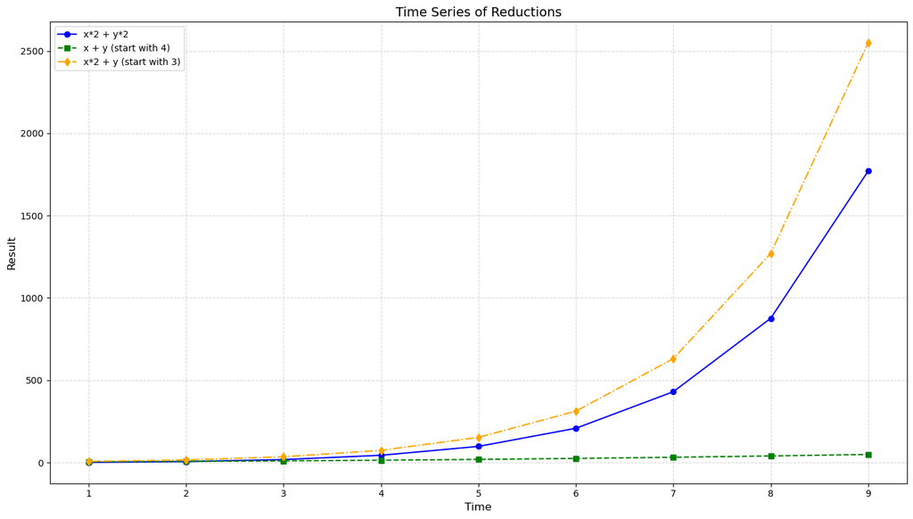

```python
import matplotlib.pyplot as plt
from functools import reduce

# Define the list of numbers
num = [1, 2, 3, 4, 5, 6, 7, 8, 9]

# Guardar las variables por separado
results_1 = []
results_2 = []
results_3 = []

# Perform incremental reductions and store results
for i in range(1, len(num) + 1):
    partial_list = num[:i]
    result_1 = reduce(lambda x, y: x*2 + y*2, partial_list)
    result_2 = reduce(lambda x, y: x + y, partial_list, 4)
    result_3 = reduce(lambda x, y: x*2 + y, partial_list, 3)

    results_1.append(result_1)
    results_2.append(result_2)
    results_3.append(result_3)

# Generate time points
time_points = list(range(1, len(num) + 1))

#---------------------------------------------
# Vizualizar los resultados

plt.figure(figsize=(14, 8))

plt.plot(time_points, results_1, label='x*2 + y*2', linestyle='-', marker='o', color='blue')
plt.plot(time_points, results_2, label='x + y (start with 4)', linestyle='--', marker='s', color='green')
plt.plot(time_points, results_3, label='x*2 + y (start with 3)', linestyle='-.', marker='d', color='orange')

plt.xlabel('Time', fontsize=12)
plt.ylabel('Result', fontsize=12)
plt.title('Time Series of Reductions', fontsize=14)
plt.legend(loc='upper left', fontsize=10)
plt.grid(True, linestyle='--', alpha=0.5)
plt.xticks(fontsize=10)
plt.yticks(fontsize=10)

plt.tight_layout()
plt.show()
```

### Las reducciones (o funciones de reducción) pueden ser herramientas en la programación para una variedad de aplicaciones en la vida real. Aquí hay algunos casos de uso comunes:

- **Procesamiento de Datos y Análisis**: Análisis de Datos Financieros: En el análisis financiero, las reducciones pueden utilizarse para calcular métricas como el rendimiento de la inversión, el valor actual neto (VAN), o la tasa interna de retorno (TIR).

Análisis de Series Temporales: Las reducciones pueden ser útiles para calcular estadísticas resumidas sobre series temporales, como la suma acumulativa de ventas diarias, el promedio móvil, o la tendencia general de los datos.

- **Ingeniería de Software y Optimización**: Optimización de Algoritmos: Las reducciones pueden ayudar a simplificar algoritmos y mejorar la eficiencia computacional al reducir una lista de valores a un resultado único.

Procesamiento de Datos en Paralelo: En entornos de procesamiento de datos distribuidos o en paralelo, las reducciones pueden ser útiles para reducir grandes conjuntos de datos en resultados manejables.

- **Modelado Matemático y Científico**: Cálculos Matemáticos y Científicos: En el modelado matemático y científico, las reducciones pueden ser utilizadas para calcular integrales, sumas de series, o realizar cálculos estadísticos sobre datos experimentales.
- **Automatización de Tareas**: Automatización de Procesos: Las reducciones pueden ser parte de scripts o programas que automatizan tareas repetitivas, como el procesamiento de archivos de datos, la generación de informes, o la limpieza de datos.
- **Manipulación de Datos en Ciencia de Datos y Machine Learning**: Preprocesamiento de Datos: En ciencia de datos y machine learning, las reducciones pueden ser útiles para transformar y resumir conjuntos de datos antes de aplicar algoritmos de modelado.

Feature Engineering: Las reducciones pueden ser utilizadas para generar nuevas características (features) a partir de conjuntos de datos existentes, condensando la información relevante en un formato más útil para los algoritmos de aprendizaje automático.